# 5 - Transformation

### Load libraries and dataframe

```r
library(tidyverse)
library(nycflights13)
library(zoo) # for computing running average
#library(fitdistrplus) #for beta distribution
```

### Exercises

1. Find all flights that
2. Had an arrival delay of two or more hours

```r
flights %>% filter(arr_delay >= 120)
```

```
## # A tibble: 10,200 x 19
##     year month   day dep_time sched_dep_time dep_delay arr_time sched_arr_time
##    <int> <int> <int>    <int>          <int>     <dbl>    <int>          <int>
##  1  2013     1     1      811            630       101     1047            830
##  2  2013     1     1      848           1835       853     1001           1950
##  3  2013     1     1      957            733       144     1056            853
##  4  2013     1     1     1114            900       134     1447           1222
##  5  2013     1     1     1505           1310       115     1638           1431
##  6  2013     1     1     1525           1340       105     1831           1626
##  7  2013     1     1     1549           1445        64     1912           1656
##  8  2013     1     1     1558           1359       119     1718           1515
##  9  2013     1     1     1732           1630        62     2028           1825
## 10  2013     1     1     1803           1620       103     2008           1750
## # ... with 10,190 more rows, and 11 more variables: arr_delay <dbl>,
## #   carrier <chr>, flight <int>, tailnum <chr>, origin <chr>, dest <chr>,
## #   air_time <dbl>, distance <dbl>, hour <dbl>, minute <dbl>, time_hour <dttm>
```

2. Flew to Houston (`IAH` or `HOU`)

```r
flights %>% filter(dest %in% c("IAH", "HOU"))
```

```
## # A tibble: 9,313 x 19
##     year month   day dep_time sched_dep_time dep_delay arr_time sched_arr_time
##    <int> <int> <int>    <int>          <int>     <dbl>    <int>          <int>
##  1  2013     1     1      517            515         2      830            819
##  2  2013     1     1      533            529         4      850            830
##  3  2013     1     1      623            627        -4      933            932
##  4  2013     1     1      728            732        -4     1041           1038
##  5  2013     1     1      739            739         0     1104           1038
##  6  2013     1     1      908            908         0     1228           1219
##  7  2013     1     1     1028           1026         2     1350           1339
##  8  2013     1     1     1044           1045        -1     1352           1351
##  9  2013     1     1     1114            900       134     1447           1222
## 10  2013     1     1     1205           1200         5     1503           1505
## # ... with 9,303 more rows, and 11 more variables: arr_delay <dbl>,
## #   carrier <chr>, flight <int>, tailnum <chr>, origin <chr>, dest <chr>,
## #   air_time <dbl>, distance <dbl>, hour <dbl>, minute <dbl>, time_hour <dttm>
```

3. Were operated by United, American, or Delta First we have to check which code has each airline

```r
airlines
```

```
## # A tibble: 16 x 2
##    carrier name
##    <chr>   <chr>
##  1 9E      Endeavor Air Inc.
##  2 AA      American Airlines Inc.
##  3 AS      Alaska Airlines Inc.
##  4 B6      JetBlue Airways
##  5 DL      Delta Air Lines Inc.
##  6 EV      ExpressJet Airlines Inc.
##  7 F9      Frontier Airlines Inc.
##  8 FL      AirTran Airways Corporation
##  9 HA      Hawaiian Airlines Inc.
## 10 MQ      Envoy Air
## 11 OO      SkyWest Airlines Inc.
## 12 UA      United Air Lines Inc.
## 13 US      US Airways Inc.
## 14 VX      Virgin America
## 15 WN      Southwest Airlines Co.
## 16 YV      Mesa Airlines Inc.
```

Then we can filter for them

```r
flights %>% filter(carrier %in% c("DL", "AA", "UA"))
```

```
## # A tibble: 139,504 x 19
##     year month   day dep_time sched_dep_time dep_delay arr_time sched_arr_time
##    <int> <int> <int>    <int>          <int>     <dbl>    <int>          <int>
##  1  2013     1     1      517            515         2      830            819
##  2  2013     1     1      533            529         4      850            830
##  3  2013     1     1      542            540         2      923            850
##  4  2013     1     1      554            600        -6      812            837
##  5  2013     1     1      554            558        -4      740            728
##  6  2013     1     1      558            600        -2      753            745
##  7  2013     1     1      558            600        -2      924            917
##  8  2013     1     1      558            600        -2      923            937
##  9  2013     1     1      559            600        -1      941            910
## 10  2013     1     1      559            600        -1      854            902
## # ... with 139,494 more rows, and 11 more variables: arr_delay <dbl>,
## #   carrier <chr>, flight <int>, tailnum <chr>, origin <chr>, dest <chr>,
## #   air_time <dbl>, distance <dbl>, hour <dbl>, minute <dbl>, time_hour <dttm>
```

4. Departed in summer (July, August, and September)

```r
flights %>% filter(month %in% 7:9)
```

```
## # A tibble: 86,326 x 19
##     year month   day dep_time sched_dep_time dep_delay arr_time sched_arr_time
##    <int> <int> <int>    <int>          <int>     <dbl>    <int>          <int>
##  1  2013     7     1        1           2029       212      236           2359
##  2  2013     7     1        2           2359         3      344            344
##  3  2013     7     1       29           2245       104      151              1
##  4  2013     7     1       43           2130       193      322             14
##  5  2013     7     1       44           2150       174      300            100
##  6  2013     7     1       46           2051       235      304           2358
##  7  2013     7     1       48           2001       287      308           2305
##  8  2013     7     1       58           2155       183      335             43
##  9  2013     7     1      100           2146       194      327             30
## 10  2013     7     1      100           2245       135      337            135
## # ... with 86,316 more rows, and 11 more variables: arr_delay <dbl>,
## #   carrier <chr>, flight <int>, tailnum <chr>, origin <chr>, dest <chr>,
## #   air_time <dbl>, distance <dbl>, hour <dbl>, minute <dbl>, time_hour <dttm>
```

5. Arrived more than two hours late, but didn’t leave late

```r
flights %>% filter(arr_delay >= 120 & dep_delay <= 0)
```

```
## # A tibble: 29 x 19
##     year month   day dep_time sched_dep_time dep_delay arr_time sched_arr_time
##    <int> <int> <int>    <int>          <int>     <dbl>    <int>          <int>
##  1  2013     1    27     1419           1420        -1     1754           1550
##  2  2013    10     7     1350           1350         0     1736           1526
##  3  2013    10     7     1357           1359        -2     1858           1654
##  4  2013    10    16      657            700        -3     1258           1056
##  5  2013    11     1      658            700        -2     1329           1015
##  6  2013     3    18     1844           1847        -3       39           2219
##  7  2013     4    17     1635           1640        -5     2049           1845
##  8  2013     4    18      558            600        -2     1149            850
##  9  2013     4    18      655            700        -5     1213            950
## 10  2013     5    22     1827           1830        -3     2217           2010
## # ... with 19 more rows, and 11 more variables: arr_delay <dbl>, carrier <chr>,
## #   flight <int>, tailnum <chr>, origin <chr>, dest <chr>, air_time <dbl>,
## #   distance <dbl>, hour <dbl>, minute <dbl>, time_hour <dttm>
```

6. Were delayed by at least an hour, but made up over 30 minutes in flight

```r
flights %>% filter(dep_delay >= 60 & arr_delay < dep_delay - 30)
```

```
## # A tibble: 1,844 x 19
##     year month   day dep_time sched_dep_time dep_delay arr_time sched_arr_time
##    <int> <int> <int>    <int>          <int>     <dbl>    <int>          <int>
##  1  2013     1     1     2205           1720       285       46           2040
##  2  2013     1     1     2326           2130       116      131             18
##  3  2013     1     3     1503           1221       162     1803           1555
##  4  2013     1     3     1839           1700        99     2056           1950
##  5  2013     1     3     1850           1745        65     2148           2120
##  6  2013     1     3     1941           1759       102     2246           2139
##  7  2013     1     3     1950           1845        65     2228           2227
##  8  2013     1     3     2015           1915        60     2135           2111
##  9  2013     1     3     2257           2000       177       45           2224
## 10  2013     1     4     1917           1700       137     2135           1950
## # ... with 1,834 more rows, and 11 more variables: arr_delay <dbl>,
## #   carrier <chr>, flight <int>, tailnum <chr>, origin <chr>, dest <chr>,
## #   air_time <dbl>, distance <dbl>, hour <dbl>, minute <dbl>, time_hour <dttm>
```

7. Departed between midnight and 6am (inclusive)

```r
flights %>% filter(dep_time %in% 0000:0600)
```

```
## # A tibble: 9,344 x 19
##     year month   day dep_time sched_dep_time dep_delay arr_time sched_arr_time
##    <int> <int> <int>    <int>          <int>     <dbl>    <int>          <int>
##  1  2013     1     1      517            515         2      830            819
##  2  2013     1     1      533            529         4      850            830
##  3  2013     1     1      542            540         2      923            850
##  4  2013     1     1      544            545        -1     1004           1022
##  5  2013     1     1      554            600        -6      812            837
##  6  2013     1     1      554            558        -4      740            728
##  7  2013     1     1      555            600        -5      913            854
##  8  2013     1     1      557            600        -3      709            723
##  9  2013     1     1      557            600        -3      838            846
## 10  2013     1     1      558            600        -2      753            745
## # ... with 9,334 more rows, and 11 more variables: arr_delay <dbl>,
## #   carrier <chr>, flight <int>, tailnum <chr>, origin <chr>, dest <chr>,
## #   air_time <dbl>, distance <dbl>, hour <dbl>, minute <dbl>, time_hour <dttm>
```

2. Another useful dplyr filtering helper is `between()`. What does it do? Can you use it to simplify the code needed to answer the previous challenges?

```r
flights %>% filter(between(month, 7, 9))
```

```
## # A tibble: 86,326 x 19
##     year month   day dep_time sched_dep_time dep_delay arr_time sched_arr_time
##    <int> <int> <int>    <int>          <int>     <dbl>    <int>          <int>
##  1  2013     7     1        1           2029       212      236           2359
##  2  2013     7     1        2           2359         3      344            344
##  3  2013     7     1       29           2245       104      151              1
##  4  2013     7     1       43           2130       193      322             14
##  5  2013     7     1       44           2150       174      300            100
##  6  2013     7     1       46           2051       235      304           2358
##  7  2013     7     1       48           2001       287      308           2305
##  8  2013     7     1       58           2155       183      335             43
##  9  2013     7     1      100           2146       194      327             30
## 10  2013     7     1      100           2245       135      337            135
## # ... with 86,316 more rows, and 11 more variables: arr_delay <dbl>,
## #   carrier <chr>, flight <int>, tailnum <chr>, origin <chr>, dest <chr>,
## #   air_time <dbl>, distance <dbl>, hour <dbl>, minute <dbl>, time_hour <dttm>
```

```r
flights %>% filter(between(dep_time, 0000, 0600))
```

```
## # A tibble: 9,344 x 19
##     year month   day dep_time sched_dep_time dep_delay arr_time sched_arr_time
##    <int> <int> <int>    <int>          <int>     <dbl>    <int>          <int>
##  1  2013     1     1      517            515         2      830            819
##  2  2013     1     1      533            529         4      850            830
##  3  2013     1     1      542            540         2      923            850
##  4  2013     1     1      544            545        -1     1004           1022
##  5  2013     1     1      554            600        -6      812            837
##  6  2013     1     1      554            558        -4      740            728
##  7  2013     1     1      555            600        -5      913            854
##  8  2013     1     1      557            600        -3      709            723
##  9  2013     1     1      557            600        -3      838            846
## 10  2013     1     1      558            600        -2      753            745
## # ... with 9,334 more rows, and 11 more variables: arr_delay <dbl>,
## #   carrier <chr>, flight <int>, tailnum <chr>, origin <chr>, dest <chr>,
## #   air_time <dbl>, distance <dbl>, hour <dbl>, minute <dbl>, time_hour <dttm>
```

3. How many flights have a missing `dep_time`? What other variables are missing? What might these rows represent?

```r
flights %>% filter(is.na(dep_time))
```

```
## # A tibble: 8,255 x 19
##     year month   day dep_time sched_dep_time dep_delay arr_time sched_arr_time
##    <int> <int> <int>    <int>          <int>     <dbl>    <int>          <int>
##  1  2013     1     1       NA           1630        NA       NA           1815
##  2  2013     1     1       NA           1935        NA       NA           2240
##  3  2013     1     1       NA           1500        NA       NA           1825
##  4  2013     1     1       NA            600        NA       NA            901
##  5  2013     1     2       NA           1540        NA       NA           1747
##  6  2013     1     2       NA           1620        NA       NA           1746
##  7  2013     1     2       NA           1355        NA       NA           1459
##  8  2013     1     2       NA           1420        NA       NA           1644
##  9  2013     1     2       NA           1321        NA       NA           1536
## 10  2013     1     2       NA           1545        NA       NA           1910
## # ... with 8,245 more rows, and 11 more variables: arr_delay <dbl>,
## #   carrier <chr>, flight <int>, tailnum <chr>, origin <chr>, dest <chr>,
## #   air_time <dbl>, distance <dbl>, hour <dbl>, minute <dbl>, time_hour <dttm>
```

```
8255 flights are missing dep_time.
Maybe they are cancelled flights, we can check if (missing dep_time - missing air_time) is empty to confirm this hypothesis.
```

```r
flights %>% filter(is.na(dep_time) & !is.na(air_time))
```

```
## # A tibble: 0 x 19
## # ... with 19 variables: year <int>, month <int>, day <int>, dep_time <int>,
## #   sched_dep_time <int>, dep_delay <dbl>, arr_time <int>,
## #   sched_arr_time <int>, arr_delay <dbl>, carrier <chr>, flight <int>,
## #   tailnum <chr>, origin <chr>, dest <chr>, air_time <dbl>, distance <dbl>,
## #   hour <dbl>, minute <dbl>, time_hour <dttm>
```

4. Why is `NA ^ 0` not missing?Why is `NA | TRUE` not missing? Why is `FALSE & NA` not missing? Can you figure out the general rule? (`NA * 0` is a tricky counterexample!)

The NA could be any number. If the number is finite, then the result of the multiplication will be 0, the exponential zero will be 1 and logical operation will show that result under any circumstance.

Counterexample: However, if the the number is Inf, then the result of the multiplication will be NaN. We don’t know if the multiplication results in 0 or NaN so the result is given as NA.

### Exercises

1. How could you use `arrange()` to sort all missing values to the start? (Hint: use `is.na()`).

First we have to check where the NAs are

```r
sapply(flights, function(x) sum(is.na(x)) )
```

```
##           year          month            day       dep_time sched_dep_time
##              0              0              0           8255              0
##      dep_delay       arr_time sched_arr_time      arr_delay        carrier
##           8255           8713              0           9430              0
##         flight        tailnum         origin           dest       air_time
##              0           2512              0              0           9430
##       distance           hour         minute      time_hour
##              0              0              0              0
```

Then for each column with NA we sort the dataset (the more NAs, the higher is the position)

```r
flights %>% arrange(desc(is.na(dep_time) +
                         is.na(arr_time) +
                         is.na(tailnum)  +
                         is.na(air_time) ))
```

```
## # A tibble: 336,776 x 19
##     year month   day dep_time sched_dep_time dep_delay arr_time sched_arr_time
##    <int> <int> <int>    <int>          <int>     <dbl>    <int>          <int>
##  1  2013     1     2       NA           1545        NA       NA           1910
##  2  2013     1     2       NA           1601        NA       NA           1735
##  3  2013     1     3       NA            857        NA       NA           1209
##  4  2013     1     3       NA            645        NA       NA            952
##  5  2013     1     4       NA            845        NA       NA           1015
##  6  2013     1     4       NA           1830        NA       NA           2044
##  7  2013     1     5       NA            840        NA       NA           1001
##  8  2013     1     7       NA            820        NA       NA            958
##  9  2013     1     8       NA           1645        NA       NA           1838
## 10  2013     1     9       NA            755        NA       NA           1012
## # ... with 336,766 more rows, and 11 more variables: arr_delay <dbl>,
## #   carrier <chr>, flight <int>, tailnum <chr>, origin <chr>, dest <chr>,
## #   air_time <dbl>, distance <dbl>, hour <dbl>, minute <dbl>, time_hour <dttm>
```

2. Sort `flights` to find the most delayed flights. Find the flights that left earliest.

   [Note that earliest refers here to the absolute time and it is not compared to the sched_dep_time]

```r
arrange(flights, desc(dep_delay), dep_time)
```

```
## # A tibble: 336,776 x 19
##     year month   day dep_time sched_dep_time dep_delay arr_time sched_arr_time
##    <int> <int> <int>    <int>          <int>     <dbl>    <int>          <int>
##  1  2013     1     9      641            900      1301     1242           1530
##  2  2013     6    15     1432           1935      1137     1607           2120
##  3  2013     1    10     1121           1635      1126     1239           1810
##  4  2013     9    20     1139           1845      1014     1457           2210
##  5  2013     7    22      845           1600      1005     1044           1815
##  6  2013     4    10     1100           1900       960     1342           2211
##  7  2013     3    17     2321            810       911      135           1020
##  8  2013     6    27      959           1900       899     1236           2226
##  9  2013     7    22     2257            759       898      121           1026
## 10  2013    12     5      756           1700       896     1058           2020
## # ... with 336,766 more rows, and 11 more variables: arr_delay <dbl>,
## #   carrier <chr>, flight <int>, tailnum <chr>, origin <chr>, dest <chr>,
## #   air_time <dbl>, distance <dbl>, hour <dbl>, minute <dbl>, time_hour <dttm>
```

3. Sort `flights` to find the fastest (highest speed) flights.

```r
arrange(flights, desc( distance/air_time ))
```

```
## # A tibble: 336,776 x 19
##     year month   day dep_time sched_dep_time dep_delay arr_time sched_arr_time
##    <int> <int> <int>    <int>          <int>     <dbl>    <int>          <int>
##  1  2013     5    25     1709           1700         9     1923           1937
##  2  2013     7     2     1558           1513        45     1745           1719
##  3  2013     5    13     2040           2025        15     2225           2226
##  4  2013     3    23     1914           1910         4     2045           2043
##  5  2013     1    12     1559           1600        -1     1849           1917
##  6  2013    11    17      650            655        -5     1059           1150
##  7  2013     2    21     2355           2358        -3      412            438
##  8  2013    11    17      759            800        -1     1212           1255
##  9  2013    11    16     2003           1925        38       17             36
## 10  2013    11    16     2349           2359       -10      402            440
## # ... with 336,766 more rows, and 11 more variables: arr_delay <dbl>,
## #   carrier <chr>, flight <int>, tailnum <chr>, origin <chr>, dest <chr>,
## #   air_time <dbl>, distance <dbl>, hour <dbl>, minute <dbl>, time_hour <dttm>
```

4. Which flights travelled the farthest? Which travelled the shortest?

Farthest flight

```r
arrange(flights, desc(distance)) %>% head(1)
```

```
## # A tibble: 1 x 19
##    year month   day dep_time sched_dep_time dep_delay arr_time sched_arr_time
##   <int> <int> <int>    <int>          <int>     <dbl>    <int>          <int>
## 1  2013     1     1      857            900        -3     1516           1530
## # ... with 11 more variables: arr_delay <dbl>, carrier <chr>, flight <int>,
## #   tailnum <chr>, origin <chr>, dest <chr>, air_time <dbl>, distance <dbl>,
## #   hour <dbl>, minute <dbl>, time_hour <dttm>
```

Shortest non cancelled flight (second row)

```r
arrange(flights, distance) %>% head(2)
```

```
## # A tibble: 2 x 19
##    year month   day dep_time sched_dep_time dep_delay arr_time sched_arr_time
##   <int> <int> <int>    <int>          <int>     <dbl>    <int>          <int>
## 1  2013     7    27       NA            106        NA       NA            245
## 2  2013     1     3     2127           2129        -2     2222           2224
## # ... with 11 more variables: arr_delay <dbl>, carrier <chr>, flight <int>,
## #   tailnum <chr>, origin <chr>, dest <chr>, air_time <dbl>, distance <dbl>,
## #   hour <dbl>, minute <dbl>, time_hour <dttm>
```

### Exercises

1. Brainstorm as many ways as possible to select `dep_time`, `dep_delay`, `arr_time`, and `arr_delay` from `flights`.

```r
flights %>% select(4, 6, 7, 9)
```

```
## # A tibble: 336,776 x 4
##    dep_time dep_delay arr_time arr_delay
##       <int>     <dbl>    <int>     <dbl>
##  1      517         2      830        11
##  2      533         4      850        20
##  3      542         2      923        33
##  4      544        -1     1004       -18
##  5      554        -6      812       -25
##  6      554        -4      740        12
##  7      555        -5      913        19
##  8      557        -3      709       -14
##  9      557        -3      838        -8
## 10      558        -2      753         8
## # ... with 336,766 more rows
```

```r
flights %>% select(starts_with("dep_"), starts_with("arr_"))
```

```
## # A tibble: 336,776 x 4
##    dep_time dep_delay arr_time arr_delay
##       <int>     <dbl>    <int>     <dbl>
##  1      517         2      830        11
##  2      533         4      850        20
##  3      542         2      923        33
##  4      544        -1     1004       -18
##  5      554        -6      812       -25
##  6      554        -4      740        12
##  7      555        -5      913        19
##  8      557        -3      709       -14
##  9      557        -3      838        -8
## 10      558        -2      753         8
## # ... with 336,766 more rows
```

```r
flights %>% select(starts_with("dep_")| starts_with("arr_"))
```

```
## # A tibble: 336,776 x 4
##    dep_time dep_delay arr_time arr_delay
##       <int>     <dbl>    <int>     <dbl>
##  1      517         2      830        11
##  2      533         4      850        20
##  3      542         2      923        33
##  4      544        -1     1004       -18
##  5      554        -6      812       -25
##  6      554        -4      740        12
##  7      555        -5      913        19
##  8      557        -3      709       -14
##  9      557        -3      838        -8
## 10      558        -2      753         8
## # ... with 336,766 more rows
```

```r
flights %>% select( (contains("time") | contains("delay") ) &
                    (contains("dep")  | contains("arr")   ) &
                    !contains("sched")                      )
```

```
## # A tibble: 336,776 x 4
##    dep_time arr_time dep_delay arr_delay
##       <int>    <int>     <dbl>     <dbl>
##  1      517      830         2        11
##  2      533      850         4        20
##  3      542      923         2        33
##  4      544     1004        -1       -18
##  5      554      812        -6       -25
##  6      554      740        -4        12
##  7      555      913        -5        19
##  8      557      709        -3       -14
##  9      557      838        -3        -8
## 10      558      753        -2         8
## # ... with 336,766 more rows
```

2. What happens if you include the name of a variable multiple times in a `select()` call? It doesn’t get replicated, as in

```r
flights %>% select(arr_time, arr_time, arr_time)
```

```
## # A tibble: 336,776 x 1
##    arr_time
##       <int>
##  1      830
##  2      850
##  3      923
##  4     1004
##  5      812
##  6      740
##  7      913
##  8      709
##  9      838
## 10      753
## # ... with 336,766 more rows
```

3. What does the `any_of()` function do? Why might it be helpful in conjunction with this vector?

   ```r
   vars <- c("year", "month", "day", "dep_delay", "arr_delay")
   flights %>% select(any_of(vars))
   ```

   ```
   ## # A tibble: 336,776 x 5
   ##     year month   day dep_delay arr_delay
   ##    <int> <int> <int>     <dbl>     <dbl>
   ##  1  2013     1     1         2        11
   ##  2  2013     1     1         4        20
   ##  3  2013     1     1         2        33
   ##  4  2013     1     1        -1       -18
   ##  5  2013     1     1        -6       -25
   ##  6  2013     1     1        -4        12
   ##  7  2013     1     1        -5        19
   ##  8  2013     1     1        -3       -14
   ##  9  2013     1     1        -3        -8
   ## 10  2013     1     1        -2         8
   ## # ... with 336,766 more rows
   ```

4. Does the result of running the following code surprise you? How do the select helpers deal with case by default? How can you change that default?

‘r contains(match, ignore.case = TRUE, vars = NULL)’

````
```r
select(flights, contains("TIME"))
```
````

```r
    select(flights, contains("TIME", ignore.case = FALSE))
```

```
## # A tibble: 336,776 x 0
```

### Exercises

1. Currently `dep_time` and `sched_dep_time` are convenient to look at, but hard to compute with because they’re not really continuous numbers. Convert them to a more convenient representation of number of minutes since midnight.

```r
flights <- flights %>%
  mutate(
    dep_time_min = 60* dep_time %/% 100 + dep_time %% 100,
    arr_time_min = 60* arr_time %/% 100 + arr_time %% 100,
    sched_dep_time_min = 60* sched_dep_time %/% 100 + sched_dep_time %% 100
    )
```

1. Compare `air_time` with `arr_time - dep_time`. What do you expect to see? What do you see? What do you need to do to fix it?

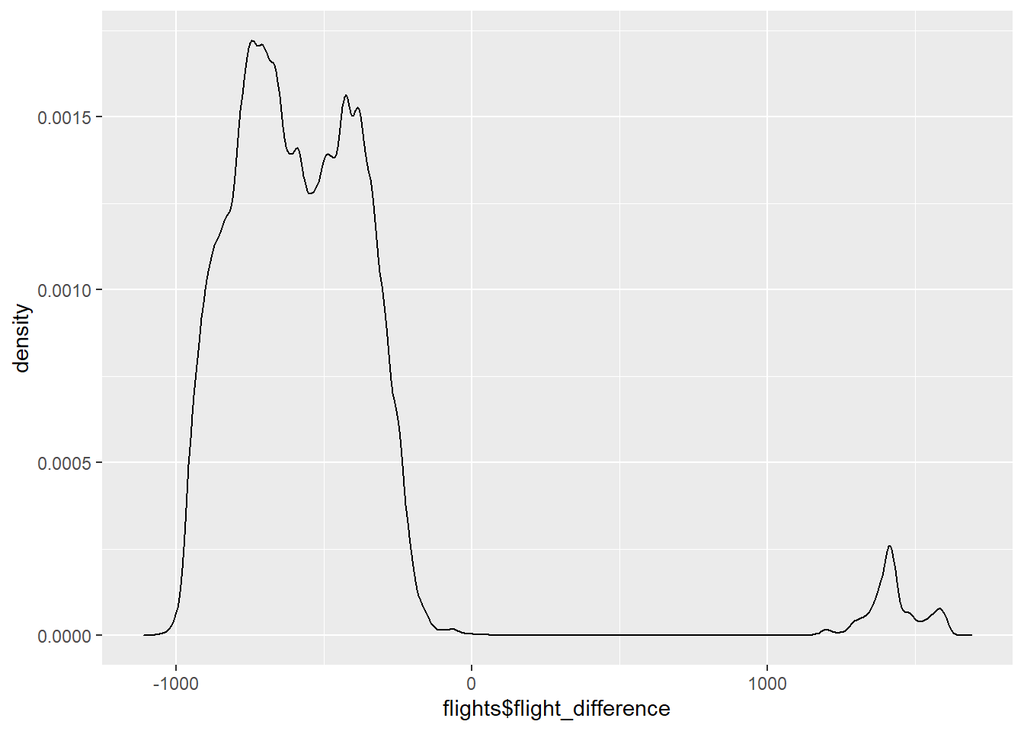

```r
flights <- flights %>%
  mutate( flight_difference = air_time - (arr_time - dep_time_min))

ggplot(flights) +
  geom_density(aes(flights$flight_difference))
```

```r
# wrong
```

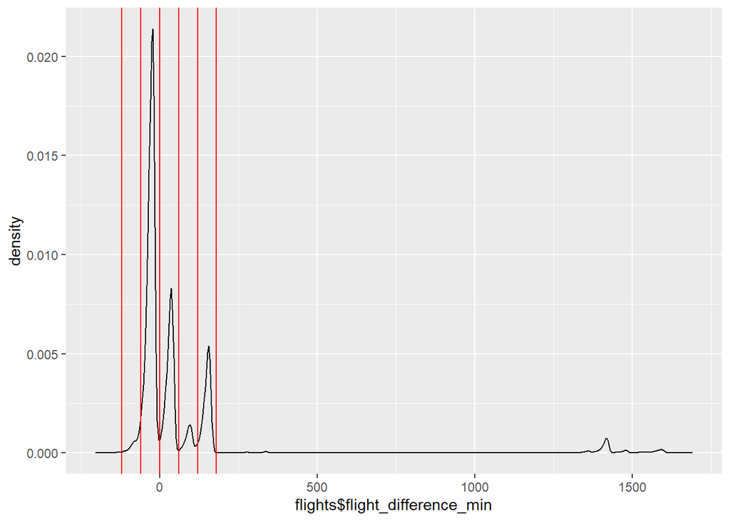

```r
flights <- flights %>%
  mutate( flight_difference_min = air_time - (arr_time_min - dep_time_min))

ggplot(flights) +
  geom_density(aes(flights$flight_difference_min)) +
  geom_vline(xintercept = c(60*(-2:3)), color = "red")
```

There is the combined effect of time zones.

Moreover, the time now is calculated using minutes since midnight to avoid effect of uncorrectly substract HHMM integers.

1. Compare `dep_time`, `sched_dep_time`, and `dep_delay`. How would you expect those three numbers to be related?

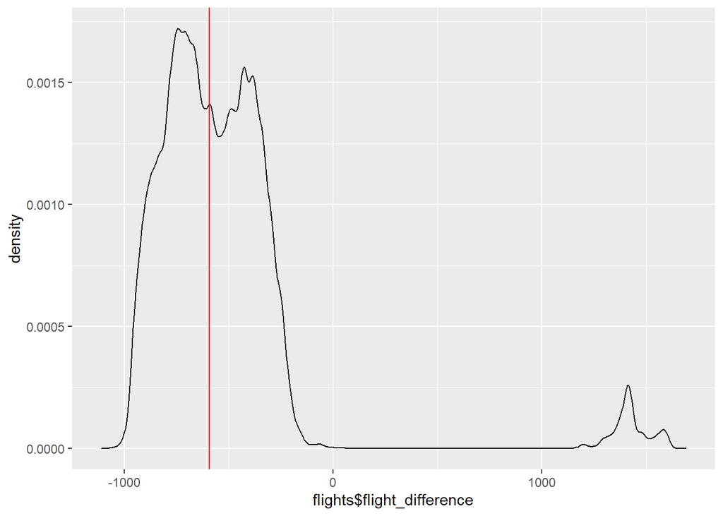

```r
flights <- flights %>%
  mutate( dep_difference = dep_delay - (dep_time_min - sched_dep_time_min))

ggplot(flights) +
  geom_density(aes(flights$flight_difference)) +
  geom_vline(xintercept = median(flights$flight_difference, na.rm = TRUE),
             color = "red")
```

They should be related as `dep_delay = (dep_time - sched_dep_time)`

1. Find the 10 most delayed flights using a ranking function. How do you want to handle ties? Carefully read the documentation for `min_rank()`.

```r
flights %>%
  select(flight, dep_time_min, sched_dep_time_min) %>%
  mutate(dep_delay_rank = min_rank(desc(dep_time_min - sched_dep_time_min))) %>%
  arrange(dep_delay_rank) %>%
  head(10)
```

```
## # A tibble: 10 x 4
##    flight dep_time_min sched_dep_time_min dep_delay_rank
##     <int>        <dbl>              <dbl>          <int>
##  1   2119         1401                490              1
##  2   2047         1377                479              2
##  3    835         1363                510              3
##  4   2319         1404                616              4
##  5    575         1161                375              5
##  6    502         1242                540              6
##  7    187         1283                630              7
##  8   1697         1381                745              8
##  9    411         1414                780              9
## 10     23         1259                630             10
```

1. What does `1:3 + 1:10` return? Why?

Error because longer object length is not a multiple of shorter object length

1. What trigonometric functions does R provide?

cos(x), sin(x), tan(x), acos(x), asin(x), atan(x), atan2(y,x)

### Exercises

1. Brainstorm at least 5 different ways to assess the typical delay characteristics of a group of flights. Consider the following scenarios:
   - A flight is 15 minutes early 50% of the time, and 15 minutes late 50% of the time.
   - A flight is always 10 minutes late.
   - A flight is 30 minutes early 50% of the time, and 30 minutes late 50% of the time.
   - 99% of the time a flight is on time. 1% of the time it’s 2 hours late.

   Which is more important: arrival delay or departure delay?

It is more important the arrival delay.

Basic assessment involves median and average delay as well as variance or IQR (filtering arr_delay > 0), count and proportion of flights with a no delay, small_delay (<20’) and significant delay (>20’).

geom_dist can provide useful insights on delay pattern for that particolar group.

```r
flights %>%
  group_by( carrier ) %>%
  summarize( prop_delay = mean( arr_delay > 0, na.rm = TRUE))
```

```
## # A tibble: 16 x 2
##    carrier prop_delay
##  * <chr>        <dbl>
##  1 9E           0.384
##  2 AA           0.335
##  3 AS           0.267
##  4 B6           0.437
##  5 DL           0.344
##  6 EV           0.479
##  7 F9           0.576
##  8 FL           0.597
##  9 HA           0.284
## 10 MQ           0.467
## 11 OO           0.345
## 12 UA           0.385
## 13 US           0.371
## 14 VX           0.341
## 15 WN           0.440
## 16 YV           0.474
```

```r
flights %>%
  group_by( carrier ) %>%
  filter ( arr_delay > 0 ) %>%
  group_by( carrier ) %>%
  summarize( mean_delay = mean(arr_delay, na.rm = TRUE),
             sd_delay = sd( arr_delay, na.rm = TRUE),
             median_delay = median( arr_delay, na.rm = TRUE),
             iqr_delay = IQR( arr_delay, na.rm = TRUE)) %>%
  arrange(desc(mean_delay))
```

```
## # A tibble: 16 x 5
##    carrier mean_delay sd_delay median_delay iqr_delay
##    <chr>        <dbl>    <dbl>        <dbl>     <dbl>
##  1 OO            60.6     56.7         47        86.2
##  2 YV            51.1     58.4         27.5      56.8
##  3 9E            49.3     58.9         27        57
##  4 EV            48.3     55.4         28        56.2
##  5 F9            47.6     70.6         24        40.2
##  6 VX            43.8     65.4         17        44
##  7 FL            41.1     61.4         19        38
##  8 WN            40.7     55.9         19        40
##  9 B6            40.0     49.2         22        44
## 10 AA            38.3     54.3         19        39
## 11 MQ            37.9     50.3         20        41
## 12 DL            37.7     59.1         17        37
## 13 UA            36.7     48.7         19        37
## 14 HA            35.0    130.          14        18
## 15 AS            34.4     41.6         17        34
## 16 US            29.0     40.8         15        28
```

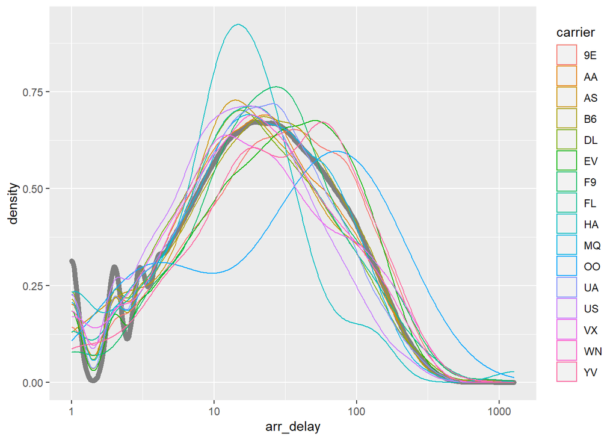

```r
ggplot(filter(flights, arr_delay > 0)) +
  geom_density( aes( x = arr_delay ), color = "grey50", size = 2) +
  geom_density( aes( x = arr_delay, color = carrier )) +
  scale_x_log10()
```

1. Come up with another approach that will give you the same output as `not_cancelled %>% count(dest)` and `not_cancelled %>% count(tailnum, wt = distance)` (without using `count()`).

```r
not_cancelled <- flights %>%
  filter(!is.na(dep_delay), !is.na(arr_delay))

not_cancelled %>%
  group_by(dest) %>%
  summarise( n() )
```

```
## # A tibble: 104 x 2
##    dest  `n()`
##  * <chr> <int>
##  1 ABQ     254
##  2 ACK     264
##  3 ALB     418
##  4 ANC       8
##  5 ATL   16837
##  6 AUS    2411
##  7 AVL     261
##  8 BDL     412
##  9 BGR     358
## 10 BHM     269
## # ... with 94 more rows
```

```r
not_cancelled %>%
  group_by(tailnum) %>%
  summarise( sum(distance) )
```

```
## # A tibble: 4,037 x 2
##    tailnum `sum(distance)`
##  * <chr>             <dbl>
##  1 D942DN             3418
##  2 N0EGMQ           239143
##  3 N10156           109664
##  4 N102UW            25722
##  5 N103US            24619
##  6 N104UW            24616
##  7 N10575           139903
##  8 N105UW            23618
##  9 N107US            21677
## 10 N108UW            32070
## # ... with 4,027 more rows
```

1. Our definition of cancelled flights (`is.na(dep_delay) | is.na(arr_delay)` ) is slightly suboptimal. Why? Which is the most important column?

We are interested only in arrived flights, which accounts also for deviations or plane crashes

1. Look at the number of cancelled flights per day. Is there a pattern? Is the proportion of cancelled flights related to the average delay?

```r
prop_cancelled <- flights %>%
  group_by( year, month, day ) %>%
  summarise( prop = mean( is.na(arr_delay) ),
             avg_delay = mean( arr_delay[arr_delay > 0], na.rm = TRUE )) %>%
  mutate( date = ISOdate(year, month, day) )
```

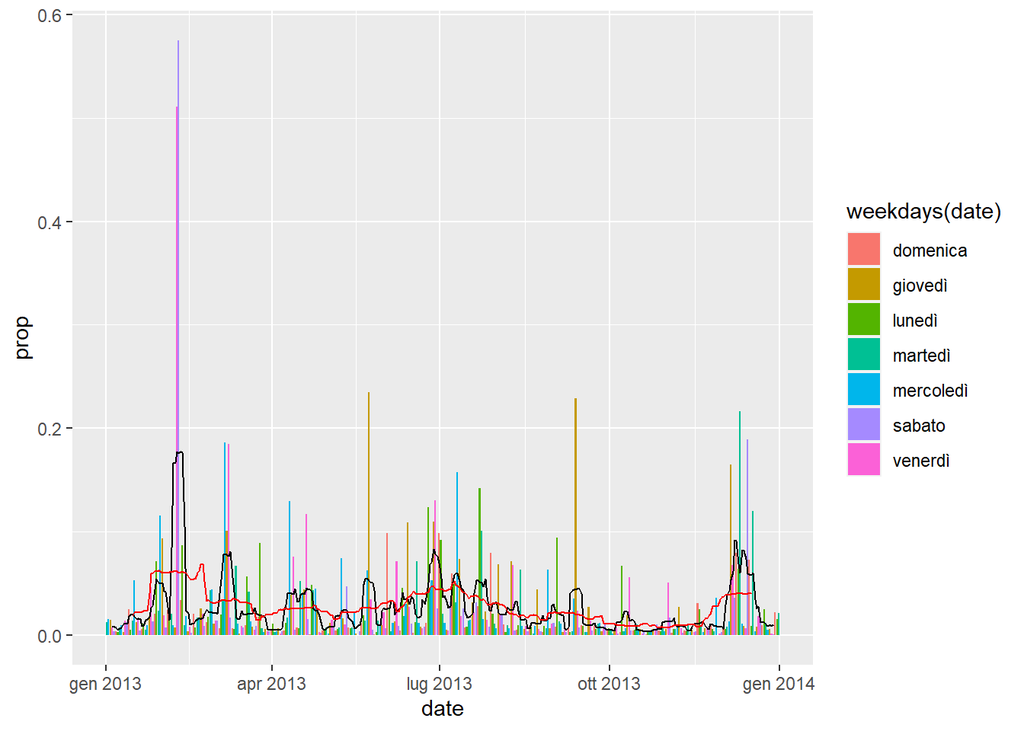

```r
ggplot(prop_cancelled) +
  geom_col( aes( x = date, y = prop, fill = weekdays(date))) +
  geom_line(aes( x = date, y=rollmean(prop, 7, fill = NA))) +
  geom_line(aes( x = date, y=rollmean(prop, 30, fill = NA)), color = "red")
```

From the plot it doesn’t seem to be a pattern, some days have higher peaks but they are not from the same day (weekday = color).

```r
weekday_cancelled <- flights %>%
  group_by( year, month, day ) %>%
  mutate( date = ISOdate(year, month, day),
          weekday = weekdays(date) ) %>%
  group_by(weekday) %>%
  summarize( prop = mean( is.na(arr_delay) )) %>%
  arrange(desc(prop))

weekday_cancelled
```

```
## # A tibble: 7 x 2
##   weekday     prop
##   <chr>      <dbl>
## 1 giovedì   0.0353
## 2 venerdì   0.0353
## 3 mercoledì 0.0285
## 4 lunedì    0.0274
## 5 martedì   0.0255
## 6 sabato    0.0239
## 7 domenica  0.0184
```

The table highlights some differences but we can not discriminate the impact of outliers (e.g. the day where 60% of flights got cancelled for saturdays and fridays)

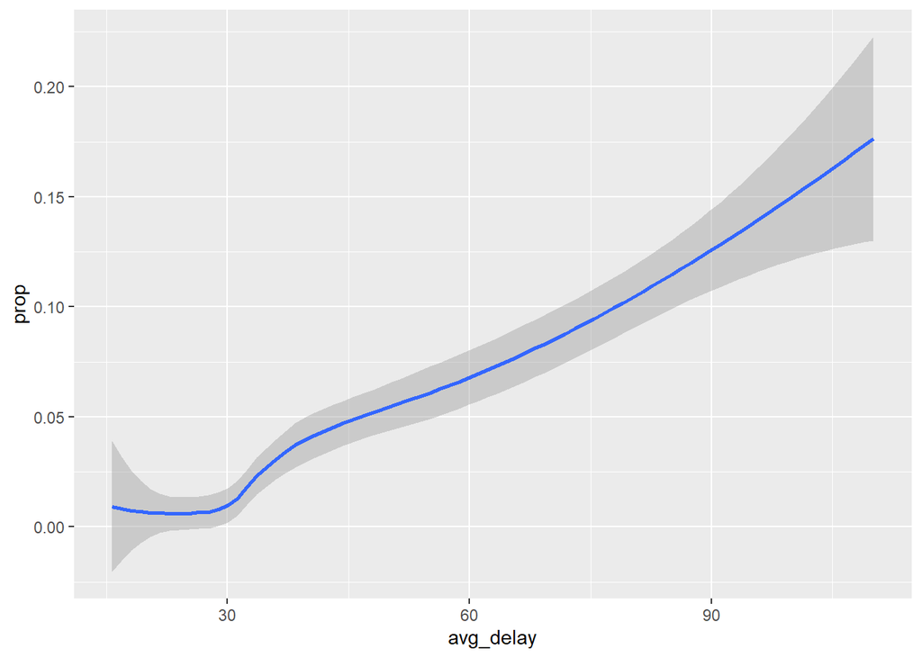

```r
ggplot(prop_cancelled, mapping = aes( x = avg_delay, y = prop)) +
  geom_smooth()
```

1. Which carrier has the worst delays? Challenge: can you disentangle the effects of bad airports vs. bad carriers? Why/why not? (Hint: think about `flights %>% group_by(carrier, dest) %>% summarise(n())`)

```r
cd_delays <- flights %>%
  group_by(carrier, dest) %>%
  summarise( total_delay = sum( dep_delay[dep_delay > 0], na.rm=TRUE) )
```

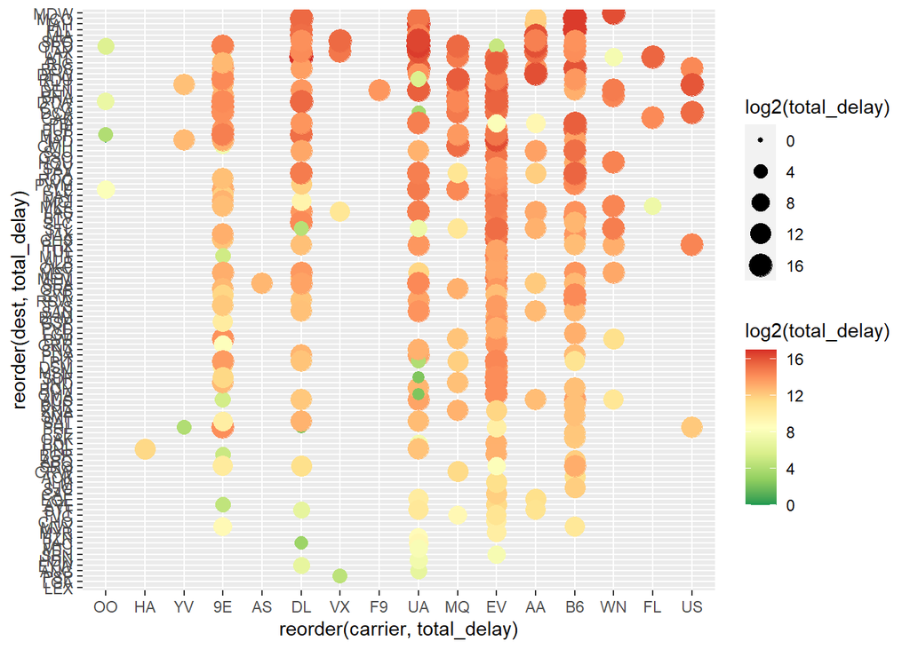

```r
ggplot(cd_delays,
       mapping = aes( x = reorder(dest,total_delay),
                      y = reorder(carrier, total_delay),
                      size = log2(total_delay),
                      color = log2(total_delay))) +
  geom_point() +
  scale_color_distiller(palette="RdYlGn") +
  coord_flip()
```

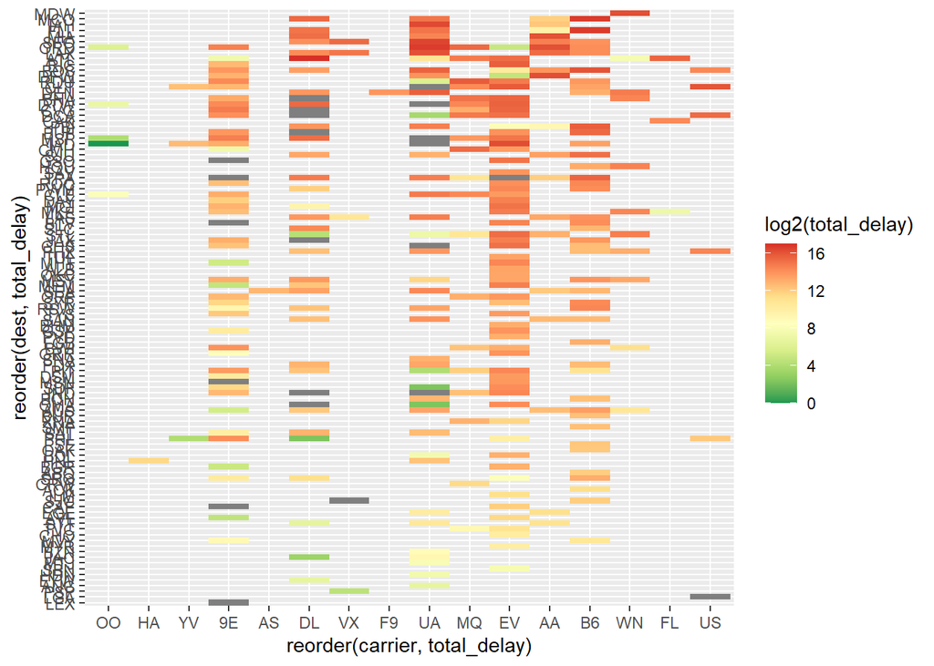

```r
ggplot(cd_delays,
       mapping = aes( x = reorder(dest,total_delay),
                      y = reorder(carrier, total_delay),
                      fill = log2(total_delay))) +
  geom_tile() +
  scale_fill_distiller(palette="RdYlGn") +
  coord_flip()
```

1. What does the `sort` argument to `count()` do. When might you use it?

If TRUE, will show the largest groups at the top. Useful not to write arrange(that variable)

### Exercises

1. Refer back to the lists of useful mutate and filtering functions. Describe how each operation changes when you combine it with grouping.
2. Which plane (`tailnum`) has the worst on-time record?

```r
delay_chart <- flights %>%
  select(tailnum, arr_delay) %>%
  group_by(tailnum) %>%
  summarise( total_flights = n(),
             on_time = ( sum( arr_delay > 0, na.rm = TRUE ) +
                         sum( is.na(arr_delay) )
                       ) / length(arr_delay) ) %>%
  filter( !is.na(tailnum)) %>%
  arrange(on_time)

delay_chart[1:10,] # print worst 10 flights
```

```
## # A tibble: 10 x 3
##    tailnum total_flights on_time
##    <chr>           <int>   <dbl>
##  1 N137DL              1       0
##  2 N14628              1       0
##  3 N1607B              3       0
##  4 N1608               3       0
##  5 N1610D              2       0
##  6 N206UA              1       0
##  7 N20904              2       0
##  8 N228UA              1       0
##  9 N27901              1       0
## 10 N306AS              1       0
```

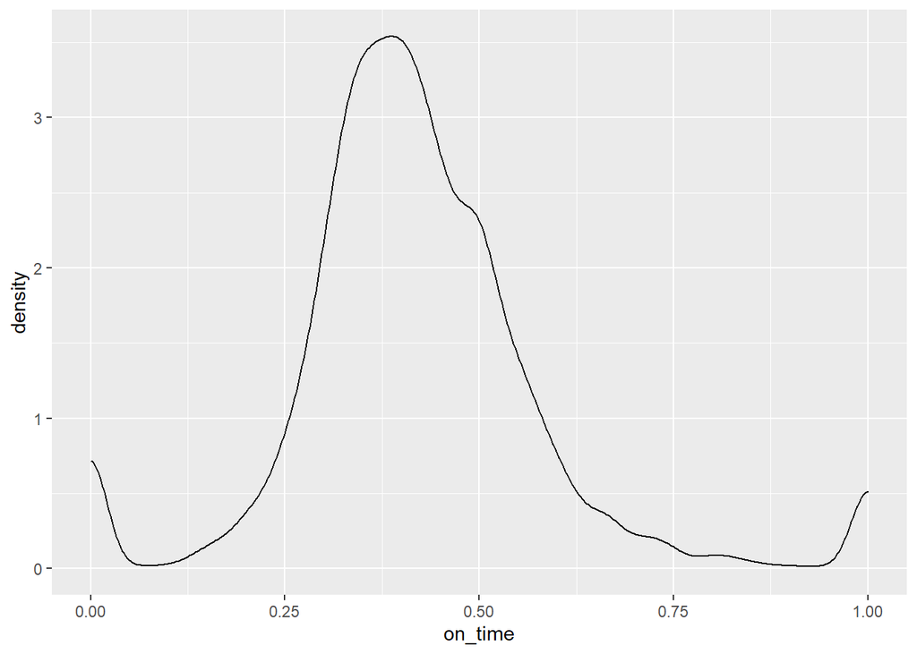

```r
ggplot(delay_chart, mapping = aes(x = on_time)) +
    geom_density()
```

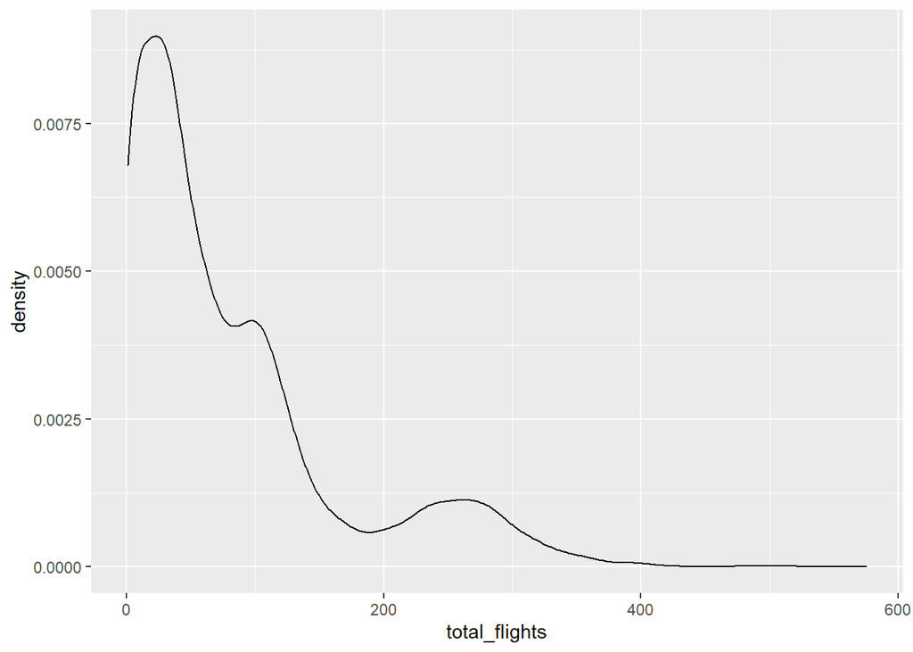

```r
ggplot(delay_chart, mapping = aes(x = total_flights)) +
    geom_density()
```

The problem with the worst flights is that maybe they have flown only few times, so they are maybe unlucky instead of chronically delayed.

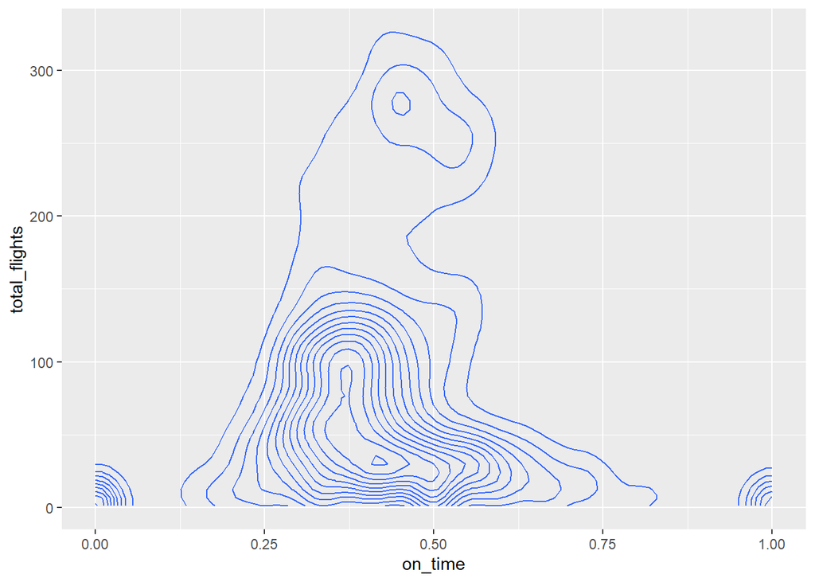

```r
ggplot(delay_chart, mapping = aes(x = on_time, y = total_flights)) +
  geom_density2d()
```

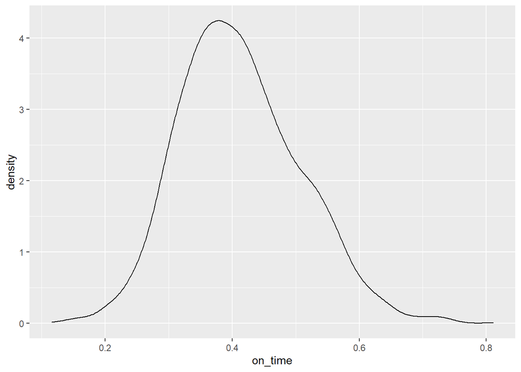

```r
ggplot(filter(delay_chart, total_flights > 20), mapping = aes(x = on_time)) +
    geom_density()
```

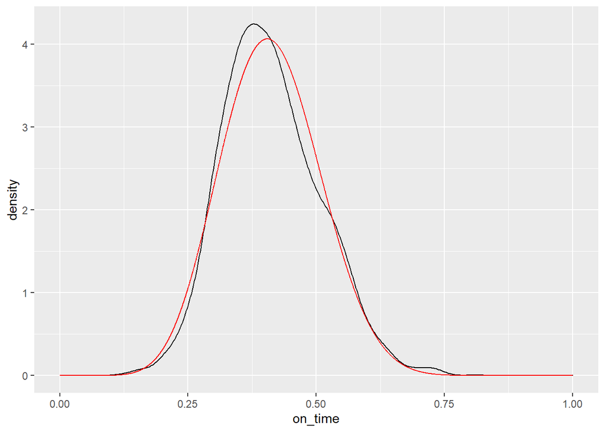

```r
# cancel low flights noise
delay_chart_filtered <- filter(delay_chart, total_flights > 20)

# fit a beta distribution (probility of probability)
# m <- fitdistr(delay_chart_filtered$on_time, #MASS package
#               dbeta,
#               start = list(shape1 = 1, shape2 = 10))
m <- fitdistrplus::fitdist(delay_chart_filtered$on_time, "beta")

#save parameters
x  <-seq(0,1,length= dim(delay_chart_filtered)[1] )
alpha0 <- m$estimate[1]
beta0  <- m$estimate[2]
db <- dbeta(x, alpha0, beta0)

ggplot(delay_chart_filtered, mapping = aes(x = on_time)) +
    geom_density() +
    geom_line(aes(x,db), color="red")
```

Now er can update our priors

```r
delay_chart <- delay_chart %>%
  mutate( true_on_time = (on_time * total_flights + alpha0)
                         / (total_flights + alpha0 + beta0 ) ) %>%
  arrange(true_on_time)

delay_chart[1:10,]
```

```
## # A tibble: 10 x 4
##    tailnum total_flights on_time true_on_time
##    <chr>           <int>   <dbl>        <dbl>
##  1 N854VA             87   0.161        0.218
##  2 N3753             130   0.185        0.222
##  3 N363NB             86   0.174        0.229
##  4 N548AA             49   0.143        0.235
##  5 N4YNAA             70   0.171        0.236
##  6 N3772H            157   0.210        0.238
##  7 N553AA             52   0.154        0.239
##  8 N847VA             91   0.198        0.245
##  9 N117UW             46   0.152        0.245
## 10 N839VA            127   0.213        0.246
```

Under the assumption that all flights are drawn from the same distribution. This result was obtained by replicating tutorial on http://varianceexplained.org/r/empirical_bayes_baseball/

1. What time of day should you fly if you want to avoid delays as much as possible?

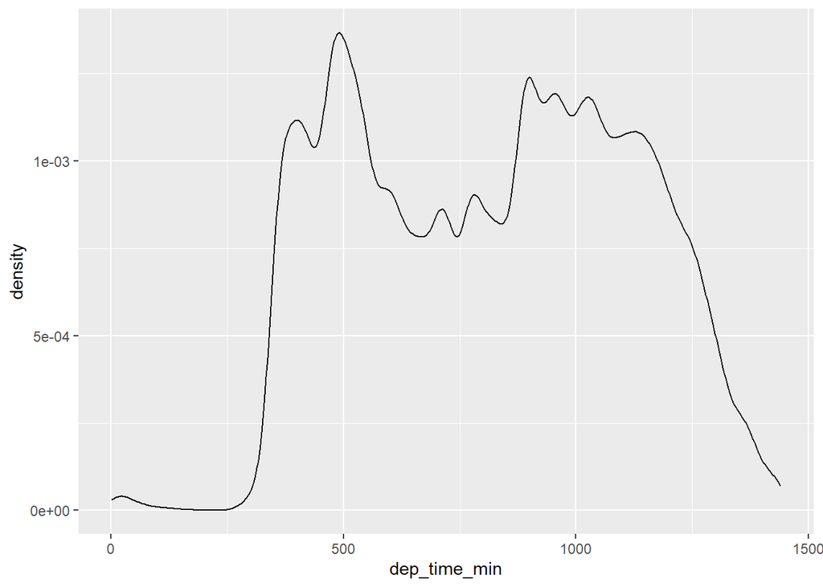

```r
ggplot(flights) +
  geom_density(aes(dep_time_min))
```

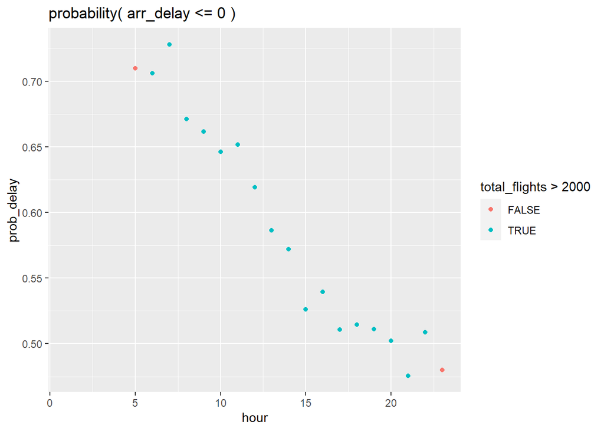

```r
hour_delay <- flights %>%
    group_by(hour) %>%
    summarise( prob_delay = mean( arr_delay <= 0, na.rm = TRUE),
               total_flights = n() ) %>%
    arrange(hour)

ggplot(hour_delay) +
  geom_point( aes(hour, prob_delay, color = total_flights > 2000) ) +
  ggtitle("probability( arr_delay <= 0 )")
```

The probability of an on time flights decreases as the hours in the day pass

1. For each destination, compute the total minutes of delay. For each flight, compute the proportion of the total delay for its destination.

```r
flights %>%
  group_by(dest) %>%
  summarise( tota_delay = sum(arr_delay * (arr_delay > 0),
                              na.rm = TRUE),
          total_flights = n())
```

```
## # A tibble: 105 x 3
##    dest  tota_delay total_flights
##  * <chr>      <dbl>         <int>
##  1 ABQ         4487           254
##  2 ACK         2974           265
##  3 ALB         9580           439
##  4 ANC           62             8
##  5 ATL       300299         17215
##  6 AUS        39940          2439
##  7 AVL         3671           275
##  8 BDL         6953           443
##  9 BGR         6940           375
## 10 BHM         7267           297
## # ... with 95 more rows
```

```r
delay_prop_flights <- flights %>%
  group_by(dest) %>%
  mutate( total_delay = sum(arr_delay * (arr_delay > 0),
                              na.rm = TRUE),
          total_flights = n()) %>%
  ungroup() %>%
  group_by(flight) %>%
  summarise( delay_proportion = (arr_delay > 0) * (arr_delay / total_delay) )
delay_prop_flights
```

```
## # A tibble: 336,776 x 2
## # Groups:   flight [3,844]
##    flight delay_proportion
##     <int>            <dbl>
##  1      1       0.0000295
##  2      1       0.000143
##  3      1       0.0000246
##  4      1       0.000118
##  5      1       0
##  6      1       0.000222
##  7      1       0
##  8      1       0.00000987
##  9      1       0
## 10      1       0
## # ... with 336,766 more rows
```

1. Delays are typically temporally correlated: even once the problem that caused the initial delay has been resolved, later flights are delayed to allow earlier flights to leave. Using `lag()`, explore how the delay of a flight is related to the delay of the immediately preceding flight.

```r
lag_flights <- flights %>%
  group_by(origin, year, month, day) %>%
  summarise( diff = lag(dep_delay) - dep_delay,
             q25 = quantile(diff, 0.25, na.rm = TRUE),
             q50 = quantile(diff, 0.25, na.rm = TRUE),
             q75 = quantile(diff, 0.25, na.rm = TRUE),
             mean = mean(diff, na.rm = TRUE) )

# ok this does not work
```

1. Look at each destination. Can you find flights that are suspiciously fast? (i.e. flights that represent a potential data entry error). Compute the air time of a flight relative to the shortest flight to that destination. Which flights were most delayed in the air?

```r
flights %>%
  group_by(dest) %>%
  mutate( mph =  (distance*60) / air_time ) %>%
  summarise( max_mph = max(mph, na.rm = TRUE) ) %>%
  arrange( desc(max_mph) )
```

```
## # A tibble: 105 x 2
##    dest  max_mph
##    <chr>   <dbl>
##  1 ATL      703.
##  2 MSP      650.
##  3 GSP      648
##  4 BNA      641.
##  5 PBI      591.
##  6 SJU      564
##  7 STT      556.
##  8 CVG      551.
##  9 BQN      550.
## 10 PSE      542.
## # ... with 95 more rows
```

Regarding the flights that got delayed the most while they were flying, we must consider - a non delayed flights takes air_time to travel between two cities - a dep_delayed flights takes air_time to travel and should arrive at air_time + dep_delay if no further delay is accumulated - in other words, arr_delay = air_time + dep_delay + mid_air_delay - or mid_air_delay = arr_delay - (air_time + dep_delay)

To see which were delayed the most…

```r
flights %>%
  mutate( mid_air_delay = arr_delay - (air_time + dep_delay) ) %>%
  group_by(flight) %>%
  summarise( max_mid_air_delay = max(mid_air_delay)) %>%
  arrange( desc(max_mid_air_delay))
```

```
## # A tibble: 3,844 x 2
##    flight max_mid_air_delay
##     <int>             <dbl>
##  1   2402                64
##  2     34                63
##  3   5667                47
##  4   2944                39
##  5   3289                34
##  6   5978                33
##  7    477                32
##  8    588                32
##  9   5329                27
## 10   1028                26
## # ... with 3,834 more rows
```

1. Find all destinations that are flown by at least two carriers. Use that information to rank the carriers.

```r
flights %>%
  group_by(dest) %>%
  mutate( more_than_1 = n_distinct(carrier) >= 2 ) %>%
  ungroup() %>%
  group_by(carrier, dest) # %>%  don't understand
```

1. For each plane, count the number of flights before the first delay of greater than 1 hour.

```r
flights %>%
  select(tailnum, time_hour, dep_delay) %>%
  group_by(tailnum) %>%
  filter( dep_delay > 60 ) %>%
  filter( rank(time_hour) == 1)
```

```
## # A tibble: 3,360 x 3
## # Groups:   tailnum [3,360]
##    tailnum time_hour           dep_delay
##    <chr>   <dttm>                  <dbl>
##  1 N531MQ  2013-01-01 06:00:00       101
##  2 N3GVAA  2013-01-01 07:00:00        71
##  3 N942MQ  2013-01-01 18:00:00       853
##  4 N534UA  2013-01-01 07:00:00       144
##  5 N76502  2013-01-01 09:00:00       134
##  6 N16561  2013-01-01 09:00:00        96
##  7 N542MQ  2013-01-01 11:00:00        71
##  8 N636JB  2013-01-01 12:00:00        77
##  9 N748EV  2013-01-01 12:00:00        70
## 10 N17984  2013-01-01 13:00:00       115
## # ... with 3,350 more rows
```